# The Defendant

Standing trial in **Breast Cancer v. The Peopel of P8105** is the accused: **Breast Cancer**. Below is the official case dossier compiled by the Prosecution Team.

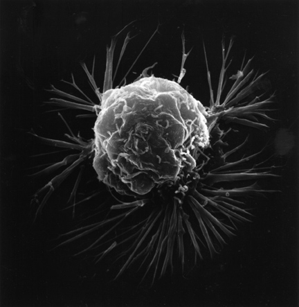

## Identity of the Defendant

**Legal Name:** Breast Cancer (Invasive and In Situ Forms)  
**Charge Category:** Malignant Neoplasm, Specializing in the Mammary Gland  
**Jurisdiction:** Global – with a particular fondness for women, but not exclusive to them.

Breast Cancer has been operating for centuries, quietly infiltrating tissues, evading early detection, and leaving a trail of loss and suffering. In this proceeding, we treat it as a repeat, high-impact offender against the public’s health.

## Known Aliases & Accomplices

- **Aliases:** “The Lump,” “The Lesion,” “The Shadow on the Mammogram.”
- **Molecular Alter Egos:** HER2-positive, Triple-Negative, Luminal A, Luminal B.
- **Accomplices (Risk Factors):**
  - Family history & BRCA mutations – the inside informants.
  - Hormonal exposures – long-term estrogen and progesterone signaling.
  - Environmental & lifestyle factors – obesity, alcohol, and inactivity playing supporting roles.
  - Structural inequities – delayed screening, limited access to care, and under-resourced health systems.

## Formal Charges

The Prosecution alleges that Breast Cancer is guilty of the following counts:

1. **Count I – Premeditated Cellular Proliferation:** Deliberate violation of normal growth controls, resulting in uncontrolled cell division.
2. **Count II – Invasion of Local Tissues:** Breaching the basement membrane and infiltrating surrounding structures without consent.
3. **Count III – Metastatic Conspiracy:** Coordinating distant spread to lymph nodes, bone, lung, liver, and brain with intent to cause systemic harm.
4. **Count IV – Disguised Presentation:** Frequently remaining asymptomatic in early stages, exploiting delays in screening and diagnosis.
5. **Count V – Exacerbating Inequities:** Disproportionately impacting marginalized communities, amplifying existing health disparities and inequities in outcomes.

## Evidence, Crime Scene & Analytic Strategy

- **Crime Scene Reconstruction:** We map the “scene” using tumor biology, treatment details, and patient characteristics to understand where, how, and in whom the harm occurs.
- **Analytic Methods as Forensics:** Regression models, survival analysis, and machine learning serve as forensic tools to quantify the impact of key factors on outcomes.
- **Survival as the Primary Charge:** We test whether specific tumor features, treatments, and delays in care meaningfully alter the probability of survival — the central count in this indictment.
- **Pattern Hunting in the Evidence:** By examining patterns across groups (e.g., stage, subtype, demographics), we search for systematic disparities that strengthen the case for guilt.

The core question of **Breast Cancer v. The Peopel of P8105** is whether these analytic investigations — of the crime scene, survival, and patterns in characteristics — provide enough evidence to convict Breast Cancer in the court of public health, or whether reasonable doubt remains.